# Investment Plan

Global Allocation Roadmap — September 2026

Published

September 23, 2026

## Situation Summary

97.4% USD

Current Currency Mix

Target: spending-based COP reserve

~$10K gap

COP Reserve Shortfall

Target ~$19.6K (18-mo spending base)

$5,200/mo

Investment Capacity

Self-directed brokerage (Fidelity/Schwab)

~4 months

COP Reserve Build

5.7%

Colombia TES Real Yield

Fisher-adjusted, USD investor

Top ETF Conviction (INDA)

India; out of 5.0 max

## Market Signal Dashboard

*Live indicators as of September 21, 2026, used to calibrate allocation decisions.*

Market Signal Dashboard

Indicator-driven modifiers applied to conviction scores

| Indicator | Current Reading | Signal | Implication |
| --- | --- | --- | --- |
| COP/USD 30-day trend | -2.2% COP gain | NA | COP allocation attractiveness |
| COP/USD 90-day trend | 8.2% COP gain | NA | COP trend confirmation |
| US Dollar Index (DXY) 30-day | 0.8% USD index change | Neutral | USD vs international positioning |
| US CPI YoY | 3.4% | ⚠ Moderate | Inflation regime: bond/equity/commodity mix |
| SPY vs VEA 60-day momentum | SPY 5.6% vs VEA 1.9% | Neutral | US vs developed-market relative weight |
| VWO vs SPY 60-day momentum | VWO 4.2% vs SPY 5.6% | Neutral | EM vs US relative weight |
| Colombia TES 10Y real yield | 5.7% (Fisher) | ✓ Attractive | Colombia fixed-income attractiveness |

**Key takeaway:** All momentum signals are currently neutral, meaning no major near-term catalysts are reinforcing or reversing the baseline conviction scores. The one standout signal is **Colombia TES real yield at 5.7%** (Fisher-adjusted) — classified as Attractive on a real-yield basis. However, the current COP/USD rate (3,193 — **2.6th percentile of the 5-year range**) means the peso is near its strongest historically, making USD→COP conversion expensive. The COP reserve will be funded via a single lump-sum wire when the rate improves. The **USD ETF portfolio is the immediate investment priority and begins now**, in parallel with — not after — the COP reserve build.

## Allocation Roadmap

The plan has two independent, parallel goals. They do not compete for capital and neither waits for the other. The $5,200/month investment contribution goes entirely to the USD ETF portfolio — always. The COP reserve is funded separately, by a one-time lump-sum wire from the liquid reserve, timed to a favorable exchange rate.

Goal 1 — COP Reserve Build (One-Time Wire, Rate-Triggered, Tax-Gated)

The COP spending reserve (~$19,600 / 62.6M COP) is funded by a **one-time lump-sum wire** from the USD liquid reserve — **not from the $5,200/month investment budget.** Execution waits for two gates: (1) COP/USD ≥ 3,917 (35th percentile, 5-year history — a daily alert fires when triggered), and (2) written CPA sign-off on §988 treatment, FBAR filing status, and Colombian withholding rate. The $5,200/month contributions to Fidelity/Schwab proceed regardless of where the COP rate stands.

Preferred COP vehicles when the transfer is executed:

Phase 1 COP Vehicle Priority — Ranked by Score

| Vehicle | Type | Nominal (%) | Real COP (%) | Risk | Fogafin | Score |
| --- | --- | --- | --- | --- | --- | --- |
| BBVA CDT 360 Days | Bank CDT | 10.5 | 4.7 | minimal | ✓ Yes | 2.4 |
| Bancolombia CDT 360 Days | Bank CDT | 10.2 | 4.5 | minimal | ✓ Yes | 2.3 |
| TES Colombia 5-Year Government Bond | Sovereign Bond | 11.2 | 5.4 | low | No | 2.3 |
| TES Colombia 30-Year Government Bond | Sovereign Bond | 12.0 | 6.2 | low | No | 2.3 |
| BBVA CDT 180 Days | Bank CDT | 10.0 | 4.3 | minimal | ✓ Yes | 2.2 |
| TES Colombia 10-Year Government Bond | Sovereign Bond | 11.5 | 5.7 | low | No | 2.1 |

**Recommended Phase 1 COP allocation:**  
- **BBVA CDT 360 Days** — 10.5% nominal / 4.7% real. Fogafin-insured up to 50M COP. Start here.  
- **Bancolombia CDT 360 Days** — 10.2% nominal / 4.5% real. Same insurance. Diversifies bank exposure.  
- **TES Colombia 5-Year** — 11.2% nominal / 5.4% real. Sovereign; no deposit insurance needed. Add once CDT limits approached.

Goal 2 — 7-Class Global Portfolio (Start Immediately, $5,200/month)

Deploy $5,200/month into Fidelity or Schwab **now**, across the target allocation below. Also deploy the liquid reserve ($309K less ~$20K COP set-aside = ~$289K deployable) over a 2–3 month window. This runs in parallel with — and does not wait for — the COP reserve build.

Phase 2 Target Allocation

Investable base ≈ $494K | Monthly DCA = $5,200 | Bond weight finalized 20% (Sep 23, 2026)

|  | Asset Class | Vehicle | Target % | Target $ (now) | Monthly $ DCA |
| --- | --- | --- | --- | --- | --- |
|  | Bonds / Ladder | VBTLX or bond ladder | 20% | $98,846 | $1,040 |
|  | U.S. Large Cap | SPY or VTI | 24% | $118,615 | $1,248 |
|  | Emerging Markets | VWO or INDA | 18% | $88,961 | $936 |
|  | International Developed | VEA | 18% | $88,961 | $936 |
|  | Cash Reserve | HYSA / Money Market | 11% | $54,365 | $572 |
|  | Commodities / Transition | COPX or URA | 5% | $24,712 | $260 |
|  | Infrastructure | GRID | 4% | $19,769 | $208 |
| Total | — | — | 100% | $494,229 | $5,200 |

### Bond Weight Derivation (Quantitative Study, Sep 23, 2026)

The 20% bond allocation is the result of a quantitative drawdown study, not a rule of thumb. The study modeled SPY (equity proxy) + AGG (bond proxy) at bond weights from 0% to 30%, holding cash fixed at 11%, using Jan 2015 – Sep 2026 monthly returns. A 2008-type stress scenario (SPY −56%, AGG +5%) was overlaid.

Bond Weight Trade-off Study — Jan 2015 – Sep 2026

SPY + AGG + 11% cash (fixed). 2008-type stress overlay (SPY −56%, AGG +5%).

| Bond % | Ann Return | Max Drawdown | $ Loss on $350K | Total Liquid at Trough |
| --- | --- | --- | --- | --- |
| 0% | 12.9% | -21.1% | -$73,920 | $585,743 |
| 15% | 11.1% | -19.7% | -$68,746 | $590,917 |
| <sup>1</sup> 20% | 10.5% | -19.2% | -$67,030 | $592,633 |
| 25% | 9.9% | -18.7% | -$65,317 | $594,346 |
| 27% | 9.7% | -18.5% | -$64,633 | $595,030 |
| 30% | 9.3% | -18.2% | -$63,608 | $596,055 |

**Why the bond weight is 20%, not higher:**

20% sits at the top of the Model Council’s recommended 15–20% range and provides meaningful drawdown ballast without meaningful opportunity cost.

## Global ETF Rankings

*Conviction scores (0–5) reflect a composite of valuation, macro tailwind, catalyst strength, implementation quality, and risk control — then adjusted by live indicator signals.*

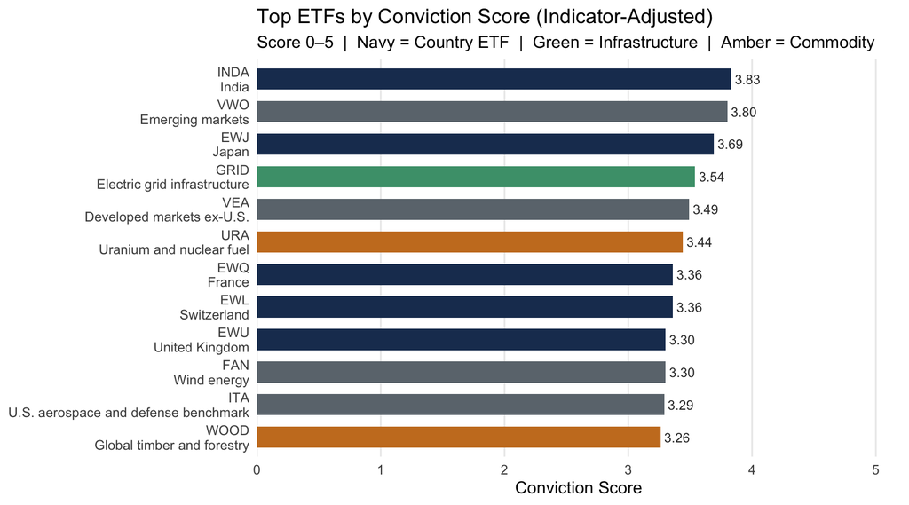

Top 10 ETFs — Key Metrics

| Symbol | Region | Ann. Return | Volatility | Max Drawdown | Sharpe | Score |
| --- | --- | --- | --- | --- | --- | --- |
| INDA | India | 7.3% | 21.1% | -45.1% | 0.35 | 3.83 |
| VWO | Emerging markets | 8.4% | 19.5% | -36.4% | 0.43 | 3.80 |
| EWJ | Japan | 10.1% | 17.8% | -33.1% | 0.57 | 3.69 |
| GRID | Electric grid infrastructure | 17.9% | 23.7% | -40.6% | 0.75 | 3.54 |
| VEA | Developed markets ex-U.S. | 10.0% | 17.4% | -35.7% | 0.58 | 3.49 |
| URA | Uranium and nuclear fuel | 15.2% | 37.1% | -66.6% | 0.41 | 3.44 |
| EWQ | France | 9.9% | 20.6% | -39.2% | 0.48 | 3.36 |
| EWL | Switzerland | 9.1% | 16.3% | -29.0% | 0.56 | 3.36 |
| EWU | United Kingdom | 8.0% | 18.8% | -43.3% | 0.43 | 3.30 |
| FAN | Wind energy | 11.3% | 21.0% | -46.3% | 0.54 | 3.30 |

## COP Investment Vehicles

*All yields shown are for a USD-based investor holding COP assets. Real COP yield uses the Fisher equation (nominal – inflation / 1 + inflation) with Colombia CPI ~5.5%. FX-adjusted yields assume COP/USD movement under three scenarios.*

COP Investment Vehicle Comparison

Ranked by composite score (real yield + risk + liquidity + insurance)

| Vehicle | Type | Nominal (%) | Real COP (%) | Risk | Fogafin | Score |
| --- | --- | --- | --- | --- | --- | --- |
| BBVA CDT 360 Days | Bank CDT | 10.5 | 4.7 | minimal | ✓ | 2.4 |
| Bancolombia CDT 360 Days | Bank CDT | 10.2 | 4.5 | minimal | ✓ | 2.3 |
| TES Colombia 5-Year Government Bond | Gov. Bond | 11.2 | 5.4 | low | – | 2.3 |
| TES Colombia 30-Year Government Bond | Gov. Bond | 12.0 | 6.2 | low | – | 2.3 |
| Ecopetrol Corporate Bond (COP) | Corp. Bond | 13.0 | 7.1 | moderate | – | 2.2 |
| BBVA CDT 180 Days | Bank CDT | 10.0 | 4.3 | minimal | ✓ | 2.2 |
| TES Colombia 10-Year Government Bond | Gov. Bond | 11.5 | 5.7 | low | – | 2.1 |
| Bancolombia Senior Bond | Corp. Bond | 12.5 | 6.6 | moderate | – | 2.0 |
| BBVA CDT 90 Days | Bank CDT | 9.5 | 3.8 | minimal | ✓ | 2.0 |
| TES Colombia 1-Year Government Bond | Gov. Bond | 10.5 | 4.7 | low | – | 2.0 |
| BBVA Savings Account | Savings | 4.0 | -1.4 | minimal | ✓ | 0.2 |
| Bancolombia Savings Account | Savings | 3.8 | -1.6 | minimal | ✓ | 0.2 |
| Ecopetrol S.A. Common Shares (EC / BVC) | equity | 5.0 | -0.5 | high | – | -1.1 |
| COLCAP Index Fund (via local broker) | equity | 2.5 | -2.8 | high | – | -2.0 |

## Investment Rationale

### COP Reserve: Parallel Liability Hedge, Not Investment Priority

The family incurs recurring COP-denominated costs (~$231/month fixed, plus ~$858/month during Colombia visits) regardless of currency performance. Wife Anna is a Colombian citizen and the family spends ~1–3 months per year in Colombia. The Colombian home (~$375K USD) is a legacy asset for son Anton and is not investable. The hedge needs to come from *liquid* COP assets sized to cover spending needs — a liability hedge, not a return-maximizing investment.

**Why the USD ETF portfolio takes priority over the COP reserve right now:**

The current COP/USD rate (3,193 — 2.6th percentile, 5-year history) means the peso is near its strongest in five years. This is the worst time to rush USD→COP conversion:

- **Opportunity cost of delaying the USD portfolio:** At 7.5% expected return on ~$310K deployable, each month of delay costs roughly **$1,938 in foregone expected returns**.
- **Cost of rushing the COP reserve at today’s rate:** Funding the 62.6M COP reserve now costs ~$19,602. Waiting for the 35th-percentile rate (~3,917 COP/USD) reduces that to ~$15,977 — a **$3,625 savings for roughly 0–11 months of patience**.
- **The math favors starting the USD portfolio immediately** and executing the COP reserve wire when the rate trigger fires. The two goals are funded from different capital pools (COP reserve from liquid reserve; USD portfolio from $5,200/month + reserve deployment) and do not compete.

**What the COP reserve actually is:**

A **spending-based liability hedge** (~$19,600 / 62.6M COP) covering 18 months of Colombia-linked costs across two Fogafin-insured institutions. It is funded by a single lump-sum wire when both gates are cleared — not by monthly contributions. After full U.S. and Colombian tax accounting, CDTs do not outperform USD T-bills in dollar terms; their value is spending-coverage certainty, not excess yield.

**Reserve vehicle summary (for when the transfer executes):**

- **CDT deposits at BBVA/Bancolombia:** 10.2–10.5% nominal. After Colombian withholding (~7%) and U.S. tax (net of FTC), real COP yield is ~2.3% — modest, but the instrument serves as a spending hedge, not a return driver. Fogafin-insured up to 50M COP per institution.
- **TES Colombia (direct only):** 11.2% nominal / ~5.4% real. Sovereign, no deposit cap. Purchasable through Valores Bancolombia only. Do not use FICs or fiducias (PFIC risk).

**The COP reserve does not require a view that COP will appreciate.** Its purpose is to eliminate the need for ongoing USD-to-COP conversions during Colombia visits. Once funded, it simply sits in CDTs and renews at prevailing rates — no further action needed.

### Why INDA (India)?

India is the fastest-growing major economy globally and the only country with a credible multi-decade demographic tailwind. Key drivers:

- Working-age population growing through 2045 (China and Europe are contracting)
- Manufacturing supply chain diversification from China (“China+1” strategy)
- Domestic consumption story largely independent of global trade cycle
- Reforms: GST implementation, digital public infrastructure, startup ecosystem
- Valuation premium vs. EM peers is real but partially justified by growth differential

**Risk:** India is not cheap on absolute P/E. A global risk-off selloff hits Indian equities hard. Currency (INR/USD) adds volatility. Watch: current account deficit, inflation persistence, BJP policy continuity.

### Why VWO (Emerging Markets Broad)?

EM broadly trades at a significant P/E discount to the S&P 500 (~12x vs ~21x). The basket provides diversification across India, Taiwan (semiconductors), China (selective recovery exposure), Brazil (commodity link), and South Korea. VWO is liquid, low-cost, and provides instant EM breadth.

**Risk:** China is the largest single country weight (~25% of VWO); geopolitical escalation around Taiwan would hit VWO hardest. USD strength is a structural headwind to EM returns.

### Why EWJ (Japan)?

Japan is the most interesting developed market value story in a decade:

- **Corporate governance reform** (TSE pressure to raise ROE and return cash to shareholders) is a structural catalyst unlike previous “Japan is cheap” cycles
- **Yen undervaluation** is at multi-decade extremes; mean reversion provides FX tailwind for USD investors even at flat local equity prices
- Warren Buffett’s Berkshire Hathaway holding large positions in Japanese trading houses validates the deep value thesis from a credible source
- Domestic inflation is returning after 30 years, supporting nominal earnings growth

**Risk:** BOJ rate normalization can tighten financial conditions; yen appreciation helps USD returns but can pressure export-heavy earnings domestically.

### Why GRID (Electric Grid Infrastructure)?

**Conviction: Leading theme ETF by macro tailwind (4.0) and catalyst strength (3.8)**

The global electricity grid requires an estimated $20+ trillion in investment through 2050. GRID (First Trust Nasdaq Clean Edge Smart Grid Infrastructure Index Fund) gives exposure to companies building transmission, distribution, and grid modernization infrastructure — top holdings include Eaton, Quanta Services, Johnson Controls, ABB, and Schneider Electric (each roughly 7.5%–8.5%). This theme is:

- **Policy-driven** (IRA in U.S., Green Deal in Europe, India grid expansion)
- **Geopolitically resilient** — grid investment is a domestic priority in every major economy
- **Earnings visible** — equipment/capex growth (~60% Industrials), not a regulated-utility income play
- **Genuinely non-U.S.** — verified look-through (Sep 23, 2026) shows ~39% U.S. / ~61% ex-U.S., Europe-heavy (Switzerland, France, Germany, Italy, U.K.) plus Canada, South Korea, and Brazil

**Verified product identity (Sep 23, 2026):** GRID was previously *described* in this plan using PAVE’s name (Global X U.S. Infrastructure Development ETF). The ticker itself was always correct; only the label was wrong. PAVE is 100% U.S. and would work against the non-U.S. mandate — GRID is the right vehicle for this thesis. Expense ratio confirmed at 0.56%.

**Risk:** Concentrated and non-diversified — ~128–146 holdings with the top 10 at ~55%–60% of assets. 12-month volatility (~10.6%) runs above PAVE’s (~7.7%). Interest rate sensitivity (infrastructure companies carry significant debt). Regulatory risk in European markets.

### Why not U.S. Large Cap as the core position?

The S&P 500 is not excluded — it remains 24% of the Phase 2 target. However, the starting position is effectively 89% cash/liquid (which shadows USD performance). The marginal investment dollar adds more diversification and return potential in non-U.S. assets at current valuations. U.S. large cap will be built systematically in Phase 2 via SPY/VTI.

## Risks and Falsification

Key Risks and Mitigations

| Risk | Probability | Impact | Mitigation |
| --- | --- | --- | --- |
| COP/USD depreciation | Medium | Low–Med | COP assets earn 10%+ nominal; FX loss must exceed yield to lose money in USD terms |
| Colombia political instability | Medium | High | TES bonds are sovereign; CDTs have Fogafin insurance. Diversify across instrument types |
| U.S. recession / global risk-off | Medium | Medium | Guaranteed income ($7,488/mo) covers most spending; liquid reserve absorbs the rest |
| India equity correction | Low–Med | Medium | INDA position built via DCA over months; position sizing limits single-country risk |
| BOJ rate shock (Japan) | Low–Med | Low–Med | BOJ moves are telegraphed; EWJ position is modest within portfolio |
| Sustained high U.S. inflation | Low | Medium | U.S. TIPS or I-bonds can hedge; bond ladder shortens duration in high inflation |
| Spending significantly exceeds $8,315/mo | Medium | High | Non-IRA liquid reserve ($162K) provides ~27 months of total drawdown runway; monitor monthly |
| Unexpected large health expenditure | Low | High | VA + Medicare provide primary coverage; Colombian Medicina Prepagada adds backup |

### What Would Falsify This Plan?

The following would trigger a material revision of the investment approach:

1. **Colombia macro deterioration:** Policy rate cut below 8%, inflation re-accelerating above 8%, or material sovereign credit rating downgrade → reduce COP allocation and shorten durations.
2. **COP depreciation > 15% in 12 months:** The FX-adjusted yield becomes negative on CDTs. Pause new COP contributions; hold existing until maturity.
3. **U.S. recession confirmed** (two negative GDP quarters): De-risk equity exposure; extend bond ladder; increase cash reserve target to 15–20%.
4. **Monthly spending sustainably > $10,000:** Liquid runway shortens below 24 months; pause investment contributions and rebuild reserve first.
5. **India P/E > 30x on forward earnings with no growth acceleration:** Trim INDA; rotate to cheaper EM or increase VWO weighting.

## Quarterly Review Checklist

At the start of each quarter (January, April, July, October), run:

```r
source("scripts/00_quarterly_refresh.R")
```

This script automatically:

1. Refreshes ETF price data (48 tickers)
2. Regenerates global conviction scores
3. Runs the live indicator pipeline and updates allocation recommendations
4. Renders the monthly allocation brief to HTML

Then complete the manual checklist the script prints:

- Export latest Banktivity accounts as QIF → run `scripts/04_quarterly_wealth_dashboard.R`
- Run `scripts/06_colombia_economic_snapshot.R` and verify COP/USD rate
- Run `scripts/07_evaluate_colombia_investments.R` — check CDT rate quotes
- Run `scripts/08_quarterly_dual_currency_review.R` — update COP home value if needed
- Review `outputs/tables/` for any change in top ETFs or COP vehicle rankings
- Commit results to git

> **Disclaimer:** This is research and analysis only, not personalized financial advice. Consult a qualified financial advisor before making investment decisions. Past performance of referenced ETFs and securities does not guarantee future results. Yields and valuations are as of September 21, 2026, and will change.